# Predicción de partidos con Machine Learning

Eliminatorias CONCACAF - Mundial 2026

EIY403 - Introducción al Análisis de Datos

2025-10-28

# Introducción

## Contexto del proyecto

Estamos en octubre de 2025 y Costa Rica está en plena lucha por clasificar al Mundial 2026. En este proyecto, vamos a usar **machine learning** para predecir los resultados de los últimos 4 partidos del Grupo C de las eliminatorias de CONCACAF.

### Situación actual (después de 4 jornadas)

**Tabla de posiciones:**

| Posición | Equipo | Puntos | GF | GC | Dif |
| --- | --- | --- | --- | --- | --- |
| 1 | Honduras | 8 | 5 | 0 | +5 |
| 2 | Costa Rica | 6 | 11 | 8 | +3 |
| 3 | Haití | 5 | 6 | 6 | 0 |
| 4 | Nicaragua | 1 | 2 | 11 | -9 |

**Partidos restantes:**

- **Jornada 5 (13 noviembre):** Haití vs Costa Rica, Nicaragua vs Honduras
- **Jornada 6 (18 noviembre):** Costa Rica vs Honduras, Haití vs Nicaragua

Solo el primer lugar clasifica directo al Mundial. Los dos mejores segundos lugares van a repechaje.

## ¿Qué es machine learning?

**Machine learning (aprendizaje automático)** es una rama de la inteligencia artificial que permite a las computadoras aprender patrones de los datos sin ser programadas explícitamente.

### Tipos de machine learning

1. **Supervisado:** Aprendemos de ejemplos etiquetados (nuestro caso)
2. **No supervisado:** Buscamos patrones sin etiquetas
3. **Por refuerzo:** Aprendemos por prueba y error

### Nuestro enfoque: Aprendizaje supervisado

Vamos a usar datos históricos de partidos (con resultados conocidos) para entrenar un modelo que prediga resultados futuros.

# 1. Carga de librerías y datos

## Librerías necesarias

```r
# Instalación de paquetes (solo la primera vez)
# install.packages(c("tidyverse", "nnet", "caret", "knitr", "kableExtra"))

# Cargar librerías
library(tidyverse)   # Manipulación y visualización de datos
library(nnet)        # Regresión logística multinomial
library(caret)       # Entrenamiento y evaluación de modelos
library(knitr)       # Tablas bonitas
library(kableExtra)  # Más opciones para tablas
```

## Carga de datos

```r
# Leer los archivos CSV
datos_historicos <- read.csv("datos_eliminatorias_concacaf.csv", stringsAsFactors = FALSE)
estadisticas_equipos <- read.csv("estadisticas_equipos.csv", stringsAsFactors = FALSE)
partidos_predecir <- read.csv("partidos_por_predecir.csv", stringsAsFactors = FALSE)

# Ver las primeras filas
head(datos_historicos)
```

```
##        fecha equipo_local equipo_visitante goles_local goles_visitante
## 1 2025-09-05    Nicaragua       Costa Rica           1               1
## 2 2025-09-05        Haiti         Honduras           0               0
## 3 2025-09-09   Costa Rica            Haiti           3               3
## 4 2025-09-09     Honduras        Nicaragua           2               0
## 5 2025-10-09     Honduras       Costa Rica           0               0
## 6 2025-10-09    Nicaragua            Haiti           0               3
##   ranking_fifa_local ranking_fifa_visitante grupo             ronda
## 1                132                     47     C Eliminatoria_2026
## 2                 87                     65     C Eliminatoria_2026
## 3                 47                     87     C Eliminatoria_2026
## 4                 65                    132     C Eliminatoria_2026
## 5                 65                     47     C Eliminatoria_2026
## 6                132                     87     C Eliminatoria_2026
```

```r
# Ver estadísticas actuales
kable(estadisticas_equipos, caption = "Estadísticas actuales de los equipos") %>%
  kable_styling(bootstrap_options = c("striped", "hover"))
```

Estadísticas actuales de los equipos

| equipo | ranking_fifa_oct2025 | puntos_fifa | puntos_grupo | partidos_jugados | victorias | empates | derrotas | goles_favor | goles_contra | diferencia_goles | forma_reciente |
| --- | --- | --- | --- | --- | --- | --- | --- | --- | --- | --- | --- |
| Honduras | 64 | 1396 | 8 | 4 | 2 | 2 | 0 | 5 | 0 | 5 | EEWW |
| Costa Rica | 45 | 1481 | 6 | 4 | 1 | 3 | 0 | 11 | 8 | 3 | EEWEW |
| Haiti | 88 | 1269 | 5 | 4 | 1 | 2 | 1 | 6 | 6 | 0 | EEWEL |
| Nicaragua | 132 | 1120 | 1 | 4 | 0 | 1 | 3 | 2 | 11 | -9 | ELLEE |

```r
# Ver partidos a predecir
kable(partidos_predecir, caption = "Partidos por predecir") %>%
  kable_styling(bootstrap_options = c("striped", "hover"))
```

Partidos por predecir

| jornada | fecha | equipo_local | equipo_visitante | ranking_fifa_local | ranking_fifa_visitante | estadio |
| --- | --- | --- | --- | --- | --- | --- |
| 5 | 2025-11-13 | Haiti | Costa Rica | 88 | 45 | Stadion Ergilio Hato (Willemstad) |
| 5 | 2025-11-13 | Nicaragua | Honduras | 132 | 64 | Estadio Nacional (Managua) |
| 6 | 2025-11-18 | Costa Rica | Honduras | 45 | 64 | Estadio Nacional (San José) |
| 6 | 2025-11-18 | Haiti | Nicaragua | 88 | 132 | Stadion Ergilio Hato (Willemstad) |

# 2. Exploración de datos (EDA)

## Estructura de los datos

```r
# Dimensiones del dataset
cat("Total de partidos históricos:", nrow(datos_historicos), "\n")
```

```
## Total de partidos históricos: 41
```

```r
cat("Variables disponibles:", ncol(datos_historicos), "\n\n")
```

```
## Variables disponibles: 9
```

```r
# Estructura
str(datos_historicos)
```

```
## 'data.frame':    41 obs. of  9 variables:
##  $ fecha                 : chr  "2025-09-05" "2025-09-05" "2025-09-09" "2025-09-09" ...
##  $ equipo_local          : chr  "Nicaragua" "Haiti" "Costa Rica" "Honduras" ...
##  $ equipo_visitante      : chr  "Costa Rica" "Honduras" "Haiti" "Nicaragua" ...
##  $ goles_local           : int  1 0 3 2 0 0 4 3 3 0 ...
##  $ goles_visitante       : int  1 0 3 0 0 3 1 0 1 0 ...
##  $ ranking_fifa_local    : int  132 87 47 65 65 132 45 64 50 70 ...
##  $ ranking_fifa_visitante: int  47 65 87 132 47 87 132 88 66 51 ...
##  $ grupo                 : chr  "C" "C" "C" "C" ...
##  $ ronda                 : chr  "Eliminatoria_2026" "Eliminatoria_2026" "Eliminatoria_2026" "Eliminatoria_2026" ...
```

## Distribución de resultados

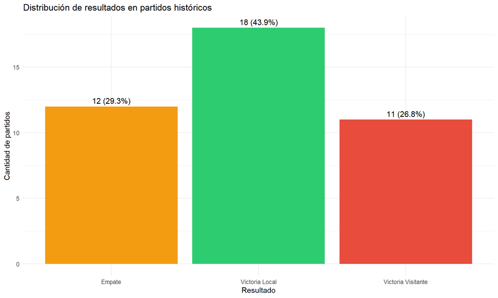

```r
# Crear variable de resultado
datos_historicos <- datos_historicos %>%
  mutate(
    resultado = case_when(
      goles_local > goles_visitante ~ "Victoria Local",
      goles_local < goles_visitante ~ "Victoria Visitante",
      TRUE ~ "Empate"
    )
  )

# Contar resultados
tabla_resultados <- datos_historicos %>%
  count(resultado) %>%
  mutate(porcentaje = round(n / sum(n) * 100, 1))

# Visualizar
ggplot(tabla_resultados, aes(x = resultado, y = n, fill = resultado)) +
  geom_col() +
  geom_text(aes(label = paste0(n, " (", porcentaje, "%)")),
            vjust = -0.5, size = 4) +
  labs(title = "Distribución de resultados en partidos históricos",
       x = "Resultado", y = "Cantidad de partidos") +
  theme_minimal() +
  theme(legend.position = "none") +
  scale_fill_manual(values = c("Victoria Local" = "#2ecc71",
                                "Empate" = "#f39c12",
                                "Victoria Visitante" = "#e74c3c"))
```

**Observaciones clave:**

- **Victoria local:** 43.9% de los partidos (18 de 41)
- **Empate:** 29.3% de los partidos (12 de 41)
- **Victoria visitante:** 26.8% de los partidos (11 de 41)

El equipo local tiene una ventaja moderada pero no abrumadora. La frecuencia alta de empates (casi 30%) es típica en partidos de eliminatorias, donde los equipos tienden a jugar más conservadores para no arriesgar puntos. Esto será importante para nuestro modelo.

## Análisis por equipo

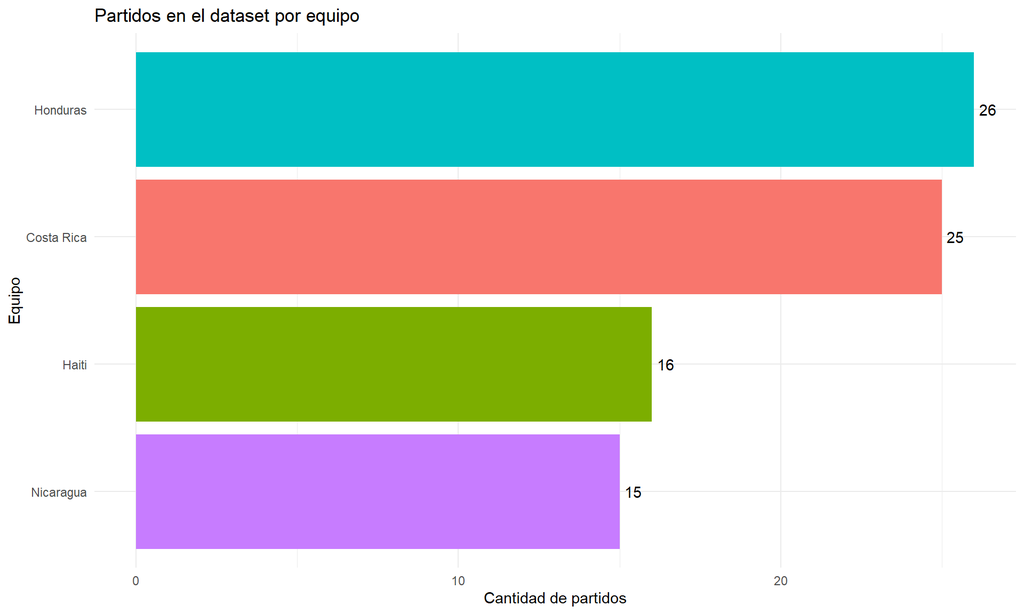

```r
# Partidos jugados por cada equipo
partidos_equipo <- datos_historicos %>%
  gather(key = "tipo", value = "equipo", equipo_local, equipo_visitante) %>%
  count(equipo) %>%
  arrange(desc(n))

ggplot(partidos_equipo, aes(x = reorder(equipo, n), y = n, fill = equipo)) +
  geom_col() +
  coord_flip() +
  geom_text(aes(label = n), hjust = -0.3) +
  labs(title = "Partidos en el dataset por equipo",
       x = "Equipo", y = "Cantidad de partidos") +
  theme_minimal() +
  theme(legend.position = "none")
```

**Observación:** Honduras y Costa Rica son los equipos con más partidos en el dataset (26 y 25 respectivamente), lo que significa que el modelo tendrá más información histórica sobre estos equipos. Haití y Nicaragua tienen menos datos (16 y 15 partidos), lo que podría afectar la precisión de las predicciones que los involucren.

## Promedios de goles

```r
# Goles promedio por partido
cat("Goles promedio por partido:",
    round(mean(datos_historicos$goles_local + datos_historicos$goles_visitante), 2), "\n")
```

```
## Goles promedio por partido: 2.63
```

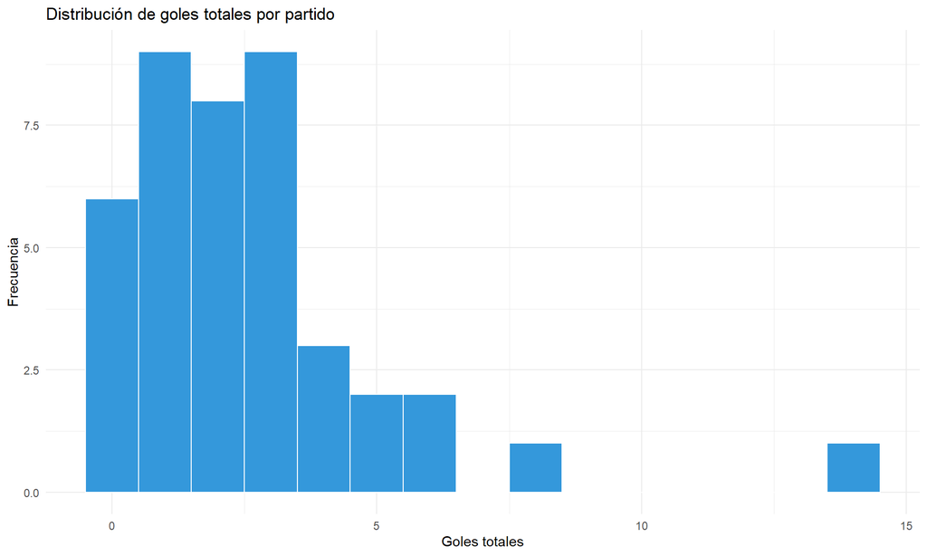

```r
# Distribución de goles totales
datos_historicos %>%
  mutate(goles_totales = goles_local + goles_visitante) %>%
  ggplot(aes(x = goles_totales)) +
  geom_histogram(binwidth = 1, fill = "#3498db", color = "white") +
  labs(title = "Distribución de goles totales por partido",
       x = "Goles totales", y = "Frecuencia") +
  theme_minimal()
```

**Observación:** Con un promedio de 2.63 goles por partido, estos partidos de CONCACAF tienden a ser relativamente ofensivos. La mayoría de partidos (más del 70%) tienen entre 1 y 4 goles totales, con algunos partidos excepcionales de más de 6 goles.

## Influencia del ranking FIFA

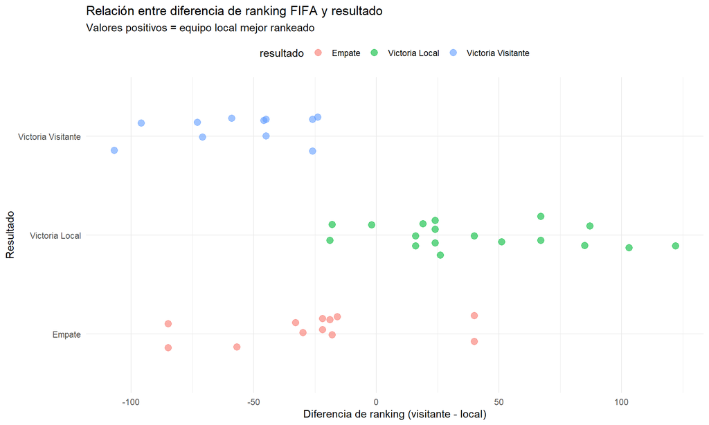

```r
# Crear diferencia de ranking (positivo = local mejor rankeado)
datos_historicos <- datos_historicos %>%
  mutate(diferencia_ranking = ranking_fifa_visitante - ranking_fifa_local)

# Visualizar relación
ggplot(datos_historicos, aes(x = diferencia_ranking, y = resultado, color = resultado)) +
  geom_jitter(width = 0, height = 0.2, size = 3, alpha = 0.6) +
  labs(title = "Relación entre diferencia de ranking FIFA y resultado",
       subtitle = "Valores positivos = equipo local mejor rankeado",
       x = "Diferencia de ranking (visitante - local)",
       y = "Resultado") +
  theme_minimal() +
  theme(legend.position = "top")
```

**Observaciones importantes:**

- Cuando la diferencia de ranking es alta (>50 posiciones a favor del local), el equipo local tiende a ganar
- Cuando la diferencia es muy negativa (<-50, visitante mucho mejor ranqueado), el visitante tiende a ganar
- En el rango de -20 a +20 posiciones de diferencia, los resultados son mucho más impredecibles
- Esto confirma que el **ranking FIFA es un predictor útil, pero NO determinante por sí solo**

Esta visualización nos sugiere que el ranking FIFA debe ser una variable importante en nuestro modelo, pero probablemente necesitemos más variables para mejorar las predicciones en partidos parejos.

# 3. Ingeniería de características (Feature Engineering)

Vamos a crear las variables que el modelo usará para hacer predicciones.

```r
# Crear características para el modelo
datos_modelo <- datos_historicos %>%
  mutate(
    # Diferencia de ranking FIFA
    dif_ranking = ranking_fifa_visitante - ranking_fifa_local,

    # Ventaja de local (siempre 1 para el dataset de entrenamiento)
    es_local = 1,

    # Resultado numérico para el modelo
    resultado_numerico = case_when(
      resultado == "Victoria Local" ~ 2,
      resultado == "Empate" ~ 1,
      resultado == "Victoria Visitante" ~ 0
    ),

    # Diferencia de goles
    dif_goles = goles_local - goles_visitante,

    # Es eliminatoria (más conservador)
    es_eliminatoria = ifelse(grepl("Eliminatoria", ronda), 1, 0)
  )

# Ver resumen de nuevas variables
summary(datos_modelo[, c("dif_ranking", "resultado_numerico", "dif_goles", "es_eliminatoria")])
```

```
##   dif_ranking       resultado_numerico   dif_goles       es_eliminatoria
##  Min.   :-107.000   Min.   :0.000      Min.   :-4.0000   Min.   :0.0000
##  1st Qu.: -45.000   1st Qu.:0.000      1st Qu.:-1.0000   1st Qu.:0.0000
##  Median : -18.000   Median :1.000      Median : 0.0000   Median :0.0000
##  Mean   :  -4.707   Mean   :1.171      Mean   : 0.5366   Mean   :0.3415
##  3rd Qu.:  26.000   3rd Qu.:2.000      3rd Qu.: 2.0000   3rd Qu.:1.0000
##  Max.   : 122.000   Max.   :2.000      Max.   : 8.0000   Max.   :1.0000
```

## Matriz de correlación

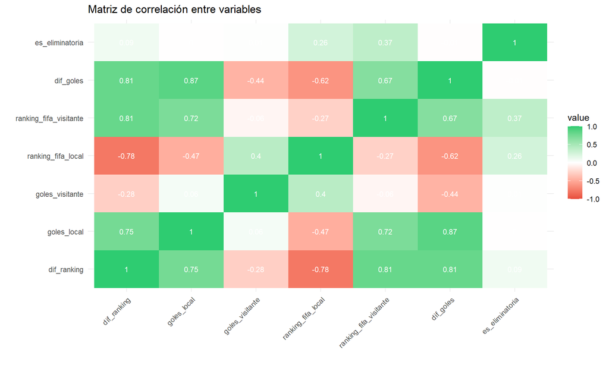

```r
# Seleccionar variables numéricas
vars_numericas <- datos_modelo %>%
  select(dif_ranking, goles_local, goles_visitante,
         ranking_fifa_local, ranking_fifa_visitante,
         dif_goles, es_eliminatoria) %>%
  na.omit()

# Calcular correlación
cor_matrix <- cor(vars_numericas)

# Visualizar con heatmap simple
library(reshape2)
cor_melted <- melt(cor_matrix)

ggplot(cor_melted, aes(x = Var1, y = Var2, fill = value)) +
  geom_tile() +
  geom_text(aes(label = round(value, 2)), color = "white", size = 3) +
  scale_fill_gradient2(low = "#e74c3c", mid = "white", high = "#2ecc71",
                       midpoint = 0, limit = c(-1, 1)) +
  labs(title = "Matriz de correlación entre variables",
       x = "", y = "") +
  theme_minimal() +
  theme(axis.text.x = element_text(angle = 45, hjust = 1))
```

**Análisis de correlaciones importantes:**

- `dif_ranking` está altamente correlacionado con `ranking_fifa_visitante` (0.81) y `dif_goles` (0.81)
- `goles_local` y `dif_goles` tienen correlación muy alta (0.87), lo cual tiene sentido
- La variable `es_eliminatoria` tiene correlaciones bajas con las demás variables (0.26-0.37)

Esto nos da pistas sobre qué variables incluir en nuestros modelos. Variables con alta correlación entre sí podrían causar multicolinealidad, así que debemos ser cuidadosos.

# 4. Preparación de datos para modelado

## División en conjunto de entrenamiento y prueba

```r
# Establecer semilla para reproducibilidad
set.seed(42)

# Crear índices para división 80-20
indices_train <- createDataPartition(datos_modelo$resultado_numerico,
                                     p = 0.8,
                                     list = FALSE)

# Dividir datos
train_data <- datos_modelo[indices_train, ]
test_data <- datos_modelo[-indices_train, ]

cat("Datos de entrenamiento:", nrow(train_data), "partidos\n")
```

```
## Datos de entrenamiento: 34 partidos
```

```r
cat("Datos de prueba:", nrow(test_data), "partidos\n")
```

```
## Datos de prueba: 7 partidos
```

**Nota importante:** Con solo 41 partidos totales, el conjunto de prueba es muy pequeño (7 partidos). Esto significa que nuestras métricas de evaluación tendrán alta variabilidad, pero es la mejor división que podemos hacer con los datos disponibles.

## Verificar balance de clases

```r
# En conjunto de entrenamiento
cat("Distribución en entrenamiento:\n")
```

```
## Distribución en entrenamiento:
```

```r
table(train_data$resultado)
```

```
##
##             Empate     Victoria Local Victoria Visitante
##                 10                 15                  9
```

```r
# En conjunto de prueba
cat("\nDistribución en prueba:\n")
```

```
##
## Distribución en prueba:
```

```r
table(test_data$resultado)
```

```
##
##             Empate     Victoria Local Victoria Visitante
##                  2                  3                  2
```